# ボクセルの木化

ryamada

2018年5月13日

## 諸関数を作る

### ボクセル集合

個々の単位立方体を、その単位立方体の８頂点の一つの座標で代表させることとする。 ただし、代表頂点はx,y,z座標が最小のものとする。

```r
Vox.list <- as.matrix(expand.grid(0:2,0:2,0:2))
Vox.list
```

```
##       Var1 Var2 Var3
##  [1,]    0    0    0
##  [2,]    1    0    0
##  [3,]    2    0    0
##  [4,]    0    1    0
##  [5,]    1    1    0
##  [6,]    2    1    0
##  [7,]    0    2    0
##  [8,]    1    2    0
##  [9,]    2    2    0
## [10,]    0    0    1
## [11,]    1    0    1
## [12,]    2    0    1
## [13,]    0    1    1
## [14,]    1    1    1
## [15,]    2    1    1
## [16,]    0    2    1
## [17,]    1    2    1
## [18,]    2    2    1
## [19,]    0    0    2
## [20,]    1    0    2
## [21,]    2    0    2
## [22,]    0    1    2
## [23,]    1    1    2
## [24,]    2    1    2
## [25,]    0    2    2
## [26,]    1    2    2
## [27,]    2    2    2
```

単位立方体の代表頂点を１行とした行列である。 これが立方体(*)のボクセル集合である。

### 単位立方体の面を列挙する

単位立方体の代表座標から、６面を列挙する。

ただし、単位立方体の面は、その４頂点座標のうち座標値が最小の頂点の座標を代表座標とし、その面の向きをの情報を加えて表すことにする。

たとえば、代表座標が(u,v,w)であり、xy平面に平行な面を(u,v,w,1)と表すことにする。

yz,zx平面に平行な面は、それぞれ(u,v,w,2),(u,v,w,3)とする。

```r
my.vox.faces <- function(xyz){
    rbind(c(xyz,1),c(xyz,2),c(xyz,3),c(xyz+c(1,0,0),2),c(xyz+c(0,1,0),3),c(xyz+c(0,0,1),1))
}

face.example <- my.vox.faces(Vox.list[3,])
face.example
```

```
##      Var1 Var2 Var3
## [1,]    2    0    0 1
## [2,]    2    0    0 2
## [3,]    2    0    0 3
## [4,]    3    0    0 2
## [5,]    2    1    0 3
## [6,]    2    0    1 1
```

### 単位面の頂点を列挙する

代表座標と面の向きの情報から、その単位正方形の４頂点座標を返す関数を作る。

```r
my.face.nodes <- function(xyzw){
    xyz <- xyzw[1:3]
    w <- xyzw[4]
    if(w==1){
        ret <- rbind(xyz,xyz+c(1,0,0),xyz+c(0,1,0),xyz+c(1,1,0))
    }else if(w==2){
        ret <- rbind(xyz,xyz+c(0,1,0),xyz+c(0,0,1),xyz+c(0,1,1))
    }else{
        ret <- rbind(xyz,xyz+c(0,0,1),xyz+c(1,0,0),xyz+c(1,0,1))
    }
    return(ret)
}
my.face.nodes(face.example)
```

```
##     [,1] [,2] [,3]
## xyz    2    2    2
##        2    2    3
##        3    2    2
##        3    2    3
```

### ボクセル集合の表面を形成する面を抽出する

ボクセル集合表面の単位正方形のリストを作る。

すべてのボクセルの面を列挙し、そのうち、２つのボクセルにサンドイッチされた面を除いたものが、表面構成成分であることを利用して、以下のようにする

行列の行を比較し、同一行がない行のみを検出し、それを抽出する関数を作る。

```r
# x は行列
# 返り値はリストで、リストの第１要素は、同一行がない行か否かのboolean ベクトル
# リストの第２要素は、同一行がない行を抽出した行列
my.onlyone <- function(x){
    n <- length(x[,1])
    a <- !duplicated(x)
    b <- !duplicated(x[n:1,])[n:1]

    return(list(a & b,x[a & b,]))
}
samplex <- matrix(c(0,0,0,1,0,1,1,1),byrow=TRUE,ncol=2)
samplex
```

```
##      [,1] [,2]
## [1,]    0    0
## [2,]    0    1
## [3,]    0    1
## [4,]    1    1
```

```r
my.onlyone(samplex)
```

```
## [[1]]
## [1]  TRUE FALSE FALSE  TRUE
##
## [[2]]
##      [,1] [,2]
## [1,]    0    0
## [2,]    1    1
```

上記の関数を用いて、ボクセルリストから、表面構成面情報を取り出す。

ただし、面が立体に対してどの向きかの情報が欲しいので、以下のような出力とする。

返り値はリストで、第１要素は単位正方形情報(代表座標と向き情報)。

第２要素は、その面をもたらしたボクセルの代表頂点を含む面か、そうでない面かの識別情報ベクトル(0なら、代表頂点を含む、1なら含まない)

```r
my.vox.surface <- function(Vlist){
    faces <- matrix(0,0,4)

    for(i in 1:length(Vlist[,1])){
        faces <- rbind(faces,my.vox.faces(Vlist[i,]))

    }
    omoteura <- rep(c(0,0,0,1,1,1),length(faces[,1]))
    onlyones <- my.onlyone(faces)
    #print(onlyones[[1]])
    return(list(onlyones[[2]],omoteura[which(onlyones[[1]])]))
}

facesout <- my.vox.surface(Vox.list)
faces <- facesout[[1]]
faces.omoteura <- facesout[[2]]

head(faces)
```

```
##      Var1 Var2 Var3
## [1,]    0    0    0 1
## [2,]    0    0    0 2
## [3,]    0    0    0 3
## [4,]    1    0    0 1
## [5,]    1    0    0 3
## [6,]    2    0    0 1
```

```r
faces.omoteura
```

```
##  [1] 0 0 0 0 0 0 0 1 0 0 0 0 1 0 0 1 0 1 0 1 1 0 0 0 0 1 0 1 0 1 1 1 1 0 0
## [36] 1 0 1 0 1 1 0 1 1 1 1 0 1 1 1 1 1 1 1
```

### 表面頂点リストを作る

各表面正方形から頂点座標を取り出し、それを全部の面について合わせて、ユニークを取ることで、表面頂点座標リストを作る。

```r
my.surface.nodes <- function(faces){
    vs <- matrix(0,0,3)
    for(i in 1:length(faces[,1])){
        vs <- rbind(vs,my.face.nodes(faces[i,]))
    }
    return(unique(vs))
}

nodes <- my.surface.nodes(faces)
head(nodes)
```

```
##     Var1 Var2 Var3
## xyz    0    0    0
##        1    0    0
##        0    1    0
##        1    1    0
##        0    0    1
##        0    1    1
```

3Dプロットする。

```r
library(rgl)
```

```r
plot3d(nodes)
```

[output not shown]

### 表面頂点リストから表面四角メッシュを作る

グラフ用パッケージ igraphを用いる。

頂点ペアのユークリッド距離を計算し、その値が１であるものはメッシュグラフのエッジであることを利用して、隣接行列を作り、隣接行列からグラフオブジェクトを作る。

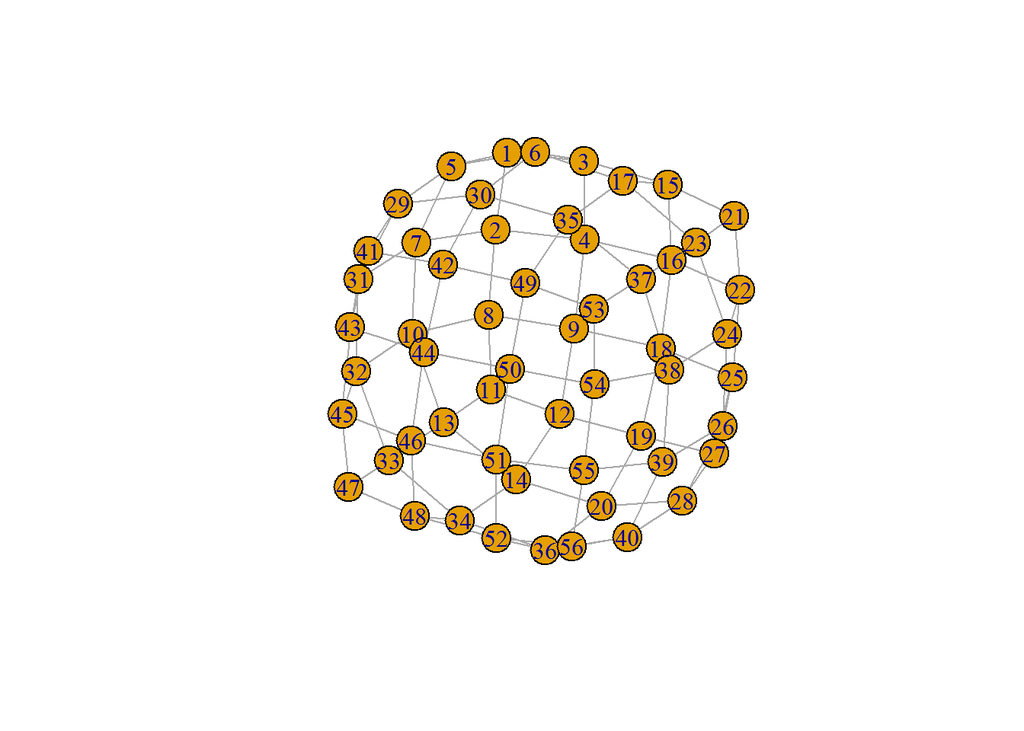

```r
library(igraph)
my.surface.graph <- function(nodes){
    d <- as.matrix(dist(nodes))
    d <- matrix(as.numeric(d==1),ncol=length(nodes[,1]))
    d
}

g <- graph.adjacency(my.surface.graph(nodes),mode="undirected")
plot(g)
```

グラフオブジェクトからエッジリストを取り出すのは簡単。

```r
edges <- t(apply(get.edgelist(g),1,sort))
```

### 単位正方形の４頂点をその順序に注意して取り出す。

表面正方形をボクセル集合の外部から眺めることにする。

そのときに、時計回りに４頂点をたどることとし、その４頂点ID(頂点座標行列の行番目)のベクトルを作成し、それを全正方形について実施して返す。

```r
my.face.nodesid <- function(faces,faces.omoteura,nodes){
    ret <- matrix(0,length(faces[,1]),4)
    for(i in 1:length(faces[,1])){
        nodes.xyz <- my.face.nodes(faces[i,])
        nodes.xyz <- nodes.xyz[c(1,2,4,3),] # 反時計回り
        if(faces[i,4]==1){
            if(faces.omoteura[i]==0){
                #nodes.xyz <- nodes.xyz[c(1,4,3,2),]
            }else{
                nodes.xyz <- nodes.xyz[c(1,4,3,2),]
            }
        }else if(faces[i,4]==2){
            if(faces.omoteura[i]==0){
                #nodes.xyz <- nodes.xyz[c(1,4,3,2),]
            }else{
                nodes.xyz <- nodes.xyz[c(1,4,3,2),]
            }
        }else{
            if(faces.omoteura[i]==0){
                #nodes.xyz <- nodes.xyz[c(1,4,3,2),]
            }else{
                nodes.xyz <- nodes.xyz[c(1,4,3,2),]
            }
        }
        nodes.id <- rep(0,4)
        for(j in 1:4){
            tmp <- t(nodes) - nodes.xyz[j,]
            tmp2 <- apply(tmp^2,2,sum)
            nodes.id[j] <- which(tmp2==0)
            ret[i,] <- nodes.id
        }
    }
    return(ret)
}

face.nodes <- my.face.nodesid(faces,faces.omoteura,nodes)
head(face.nodes)
```

```
##      [,1] [,2] [,3] [,4]
## [1,]    1    2    4    3
## [2,]    1    3    6    5
## [3,]    1    5    7    2
## [4,]    2    8    9    4
## [5,]    2    7   10    8
## [6,]    8   11   12    9
```

### 四角化グラフから木を作る

木の作成には、ルートノードの指定と、ルートノードからのグラフ距離が必要なので、まずそれをする。

１頂点を適当にルートとして選び、ルートから全頂点へのグラフ距離を求める。

```r
rootid <- 10

shdist <- distances(g) # 全頂点間のペアワイズグラフ距離を算出

rootdist <- shdist[rootid,] # ルートノードからのグラフ距離を抽出
rootdist
```

```
##  [1] 3 2 4 3 2 3 1 1 2 0 2 3 1 2 5 4 4 3 4 3 6 5 5 6 4 5 5 4 3 4 2 1 2 3 5
## [36] 4 6 7 6 5 4 5 3 4 2 3 3 4 6 5 4 5 7 6 5 6
```

木を作るにあたり、各正方形ごとに１つのエッジを以下の方法で定める。

正方形の４頂点(外から見て時計回りの４頂点)に付与されたルートノードからの距離は

1. t -> t+1 -> t+2 -> t+1の順か
2. t -> t+1 -> t -> t+1 の順か

のいずれかである。それは、隣接頂点の距離の値は必ず±1の違いになる仕組みになっているからである。

1. の場合には、値t+2の頂点と、時計回りの隣になる値t+1の頂点とを結んだエッジを作る。
2. の場合には、値t+1の２頂点を結んだ対角線をエッジとする。

以下の複数の関数は、この処理を実行するためのものである。

```r
my.tree.edge <- function(vals){ # 反時計回り
    tmp <- which(vals == max(vals))
    if(length(tmp)==2){
        ret <- tmp
        #print("diagonal")
    }else{
        ret <- c(tmp,tmp+1)
        if(ret[2] > 4){
            ret[2] <- 1
        }
    }
    return(ret)
}

my.tree.edge(c(1,2,3,2))
```

```
## [1] 3 4
```

```r
my.select.face.edge <- function(nodeid,rootdist){
    vals <- rootdist[nodeid]
    tmp <- my.tree.edge(vals)
    return(nodeid[tmp])
}

my.tree.edges <- function(face.nodes,rootdist){
    tmp <- apply(face.nodes,1,my.select.face.edge,rootdist)
    ret <- matrix(tmp,nrow=2)
    return(t(ret))
}

tree.edges <- my.tree.edges(face.nodes,rootdist)
head(tree.edges)
```

```
##      [,1] [,2]
## [1,]    3    1
## [2,]    3    6
## [3,]    1    5
## [4,]    4    2
## [5,]    2    7
## [6,]   12    9
```

### 描図する

表面四角化メッシュを黒で描き、 木を赤で描き、 ルートノードをハイライトし ルートノードとつながるべき、木のノードとの間に特別なエッジを加える(このエッジは「四角化グラフの木」には含まれない)。

```r
my.draw.surface <- function(nodes,root,edges,tree.edges=Null,axes = FALSE,radius.root = 0.1){
    plot3d(nodes,axes=axes,xlab="x",ylab="y",zlab="z")


    if(!is.null(tree.edges)){
        tmp <- c(t(tree.edges))
        segments3d(nodes[tmp,],col=2)
    }
  tmp <- c(t(edges))
    segments3d(nodes[tmp,])
    spheres3d(nodes[root,],col=3,radius=radius.root)

}

my.draw.surface(nodes,rootid,edges,tree.edges=tree.edges)
# ルートノードとつながるべきノードは、ルートノードからの距離が１なので
# そのノードを取り出し、エッジで結ぶ
one.nodes <- which(rootdist==1)
for(i in 1:length(one.nodes)){
    segments3d(rbind(nodes[rootid,],nodes[one.nodes[i],]),col="purple")
}
```

## ボクセル集合から一括処理する関数に再構成する

まず、ボクセル集合から、四角化グラフを作るところまで。

```r
my.vox2quad <- function(Vox.list){
  facesout <- my.vox.surface(Vox.list) # ボクセルリストから表面正方形を列挙
  faces <- facesout[[1]] # 表面正方形のリスト
  faces.omoteura <- facesout[[2]] # 表面正方形の向き情報
  nodes <- my.surface.nodes(faces) # 表面ノードのリスト
  g <- graph.adjacency(my.surface.graph(nodes),mode="undirected") # 表面をグラフオブジェクト化
  edges <- t(apply(get.edgelist(g),1,sort)) # 表面エッジリスト
  face.nodes <- my.face.nodesid(faces,faces.omoteura,nodes) # 表面正方形の４頂点(向き考慮)

  return(list(Vox.list=Vox.list,faces=faces,faces.omoteura=faces.omoteura,nodes=nodes,g=g,edges=edges,face.nodes=face.nodes))
}

quad <- my.vox2quad(Vox.list)
```

次に、四角化グラフに対して、ルートノードを与えて木を作るまで。

```r
my.quad2tree <- function(quad,rootid){
  shdist <- distances(quad$g) # 全頂点間のペアワイズグラフ距離を算出
  rootdist <- shdist[rootid,] # ルートノードからのグラフ距離を抽出
  tree.edges <- my.tree.edges(quad$face.nodes,rootdist) # 木構成エッジ
  return(list(quad=quad,tree.edges=tree.edges,rootid=rootid,rootdist=rootdist,shdist=shdist))
}
rootid <- 20 # ルートノードIDを適当に指定
tr <- my.quad2tree(quad,rootid)
```

結果を描画。

```r
my.draw.surface.tree <- function(tr,axes = FALSE,radius.root = 0.1){
  plot3d(tr$quad$nodes,axes=axes,xlab="x",ylab="y",zlab="z")
    #tmp <- c(t(tr$quad$edges))
    #segments3d(nodes[tmp,])
    if(!is.null(tr$tree.edges)){
        tmp <- c(t(tr$tree.edges))
        segments3d(tr$quad$nodes[tmp,],col=2)
    }
    tmp <- c(t(tr$quad$edges))
    segments3d(tr$quad$nodes[tmp,],col=gray(0.5))
    spheres3d(tr$quad$nodes[tr$rootid,],col=3,radius=radius.root)
    one.nodes <- which(tr$rootdist==1)
  for(i in 1:length(one.nodes)){
    segments3d(rbind(tr$quad$nodes[tr$rootid,],tr$quad$nodes[one.nodes[i],]),col="purple")
  }
}
my.draw.surface.tree(tr)
```

[output not shown]

## 適当にボクセルリストを作って、使ってみる

```r
n.step <- 1000
#xxx <- matrix(rep(0,3),ncol=3)
xxx <- as.matrix(expand.grid(-1:1,-1:1,-1:1))
for(i in 1:n.step){
  pr <- apply(xxx^2,1,sum)
    r <- sample(1:length(xxx[,1]),1,prob=pr+0.1)
    #p <- sample(1:3,1)
    tmp <- xxx[r,]
    p <- sample(1:3,1)
    if(runif(1)<0.5){
      p <- order(tmp)[2]
    }

    tmp[p] <- tmp[p] + 1
    xxx <- rbind(xxx,tmp)
    xxx <- unique(xxx)
}
Vox.list <- unique(xxx)
quad <- my.vox2quad(Vox.list)
rootid <- 100
tr <- my.quad2tree(quad,rootid)
```

```r
my.draw.surface.tree(tr)
```

ルートノードからの距離に応じてノードに色を付けてみる。

```r
for(i in 1:length(tr$quad$nodes[,1])){
  # グラフ距離を適当倍して大雑把にカラースケールが現れるようにする
  d <- floor(tr$rootdist[i] * 0.3) +1
  #print(d)
  spheres3d(tr$quad$nodes[i,],col=d,radius=0.1)
}
```